# Personal Activity Monitoring Assignment

Muhammad Safwan Naqi

Thursday, June 11, 2015

### Loading and preprocessing the data

First we’ll download the zip file and unzip it in our working directory.

```r
zipfile <- tempfile()
fileurl = "https://d396qusza40orc.cloudfront.net/repdata%2Fdata%2Factivity.zip"
download.file(fileurl, zipfile,  mode="wb", method = "curl")
unzip(zipfile, "activity.csv")
unlink(zipfile)
```

Next we’ll load the data in a data frame.

```r
actmondata <- read.csv("activity.csv")
```

Doing minor date tranformations using `lubridate` package

```r
actmondata$date <- as.character(actmondata$date)
library(lubridate)
actmondata$date <- ymd(actmondata$date)
```

### Analysis of data across days

We’ll first calculate the total number of steps taken per day and print them.

```r
steps_per_day <- tapply(actmondata$steps, actmondata$date, function(x) sum(x, na.rm = TRUE))
print(steps_per_day)
```

```
## 2012-10-01 2012-10-02 2012-10-03 2012-10-04 2012-10-05 2012-10-06
##          0        126      11352      12116      13294      15420
## 2012-10-07 2012-10-08 2012-10-09 2012-10-10 2012-10-11 2012-10-12
##      11015          0      12811       9900      10304      17382
## 2012-10-13 2012-10-14 2012-10-15 2012-10-16 2012-10-17 2012-10-18
##      12426      15098      10139      15084      13452      10056
## 2012-10-19 2012-10-20 2012-10-21 2012-10-22 2012-10-23 2012-10-24
##      11829      10395       8821      13460       8918       8355
## 2012-10-25 2012-10-26 2012-10-27 2012-10-28 2012-10-29 2012-10-30
##       2492       6778      10119      11458       5018       9819
## 2012-10-31 2012-11-01 2012-11-02 2012-11-03 2012-11-04 2012-11-05
##      15414          0      10600      10571          0      10439
## 2012-11-06 2012-11-07 2012-11-08 2012-11-09 2012-11-10 2012-11-11
##       8334      12883       3219          0          0      12608
## 2012-11-12 2012-11-13 2012-11-14 2012-11-15 2012-11-16 2012-11-17
##      10765       7336          0         41       5441      14339
## 2012-11-18 2012-11-19 2012-11-20 2012-11-21 2012-11-22 2012-11-23
##      15110       8841       4472      12787      20427      21194
## 2012-11-24 2012-11-25 2012-11-26 2012-11-27 2012-11-28 2012-11-29
##      14478      11834      11162      13646      10183       7047
## 2012-11-30
##          0
```

Next, we’ll make a histogram of the total number of steps taken each day

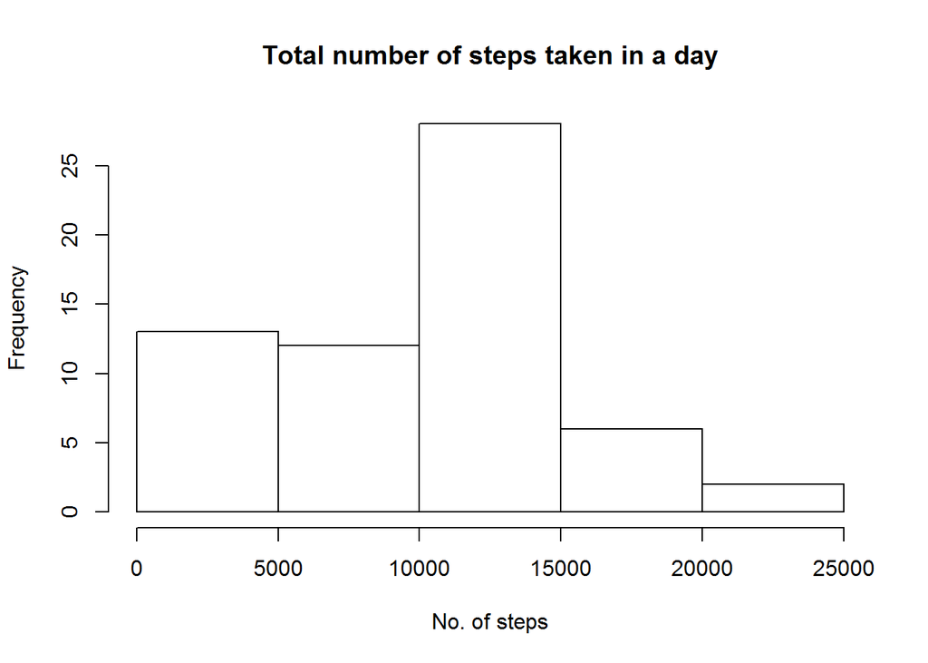

```r
hist(steps_per_day, main = "Total number of steps taken in a day", xlab = "No. of steps")
```

Final step for this section: we’ll calculate and show mean and median of the total number of steps taken per day

```r
avesteps_per_day <- mean(steps_per_day)
print(avesteps_per_day)
```

```
## [1] 9354.23
```

```r
mediansteps_per_day <- median(steps_per_day)
print(mediansteps_per_day)
```

```
## [1] 10395
```

### Average daily activity patterns

Now we’ll create a time series plot of the 5-minute interval (x-axis) and the average number of steps taken, averaged across all days (y-axis)

```r
avesteps_per_int <- tapply(actmondata$steps, actmondata$interval,
                           function(x) mean(x, na.rm = TRUE))
print(avesteps_per_int)
```

[output not shown]

[output cut: 41 more lines]

[output not shown]

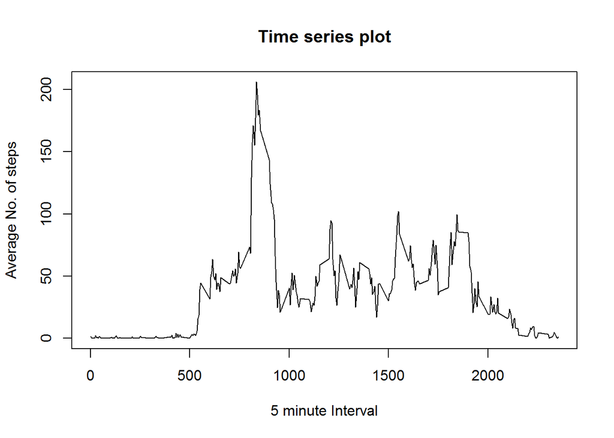

```r
plot(names(avesteps_per_int), avesteps_per_int, type = "l", xlab = "5 minute Interval",
     ylab = "Average No. of steps", main = "Time series plot")
```

Let’s find the 5-minute interval with the maximum number of steps

```r
maxint <- names(avesteps_per_int)[which.max(avesteps_per_int)]
print(maxint)
```

```
## [1] "835"
```

### Imputing missing values

Calculating and showing the total number of missing values in the dataset

```r
tot_missing_values <- sum(!complete.cases(actmondata))
print(tot_missing_values)
```

```
## [1] 2304
```

Imputing all of the missing values in the dataset: I believe that the movement activity, especially walking, of any individual is highly dependant of the time of the day. We usually don’t walk at night as most of us are asleep, and we immediately start walking around after waking up in the morning to go to work, school etc. Hence I have decided to impute my data for each interval with the mean value of that interval across all other dates.

```r
imputed_data <- actmondata
missing_values <- is.na(imputed_data$steps)
imputed_data[missing_values, "steps"] <-
    avesteps_per_int[as.character(imputed_data[missing_values, "interval"])]
```

Making a histogram of the total number of steps taken each day using the imputed data

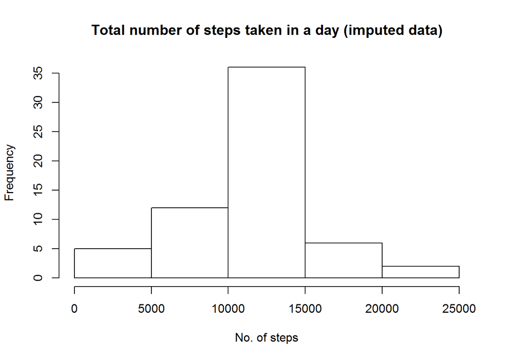

```r
imp_steps_per_day <- tapply(imputed_data$steps, imputed_data$date, sum)
hist(imp_steps_per_day, main = "Total number of steps taken in a day (imputed data)",
     xlab = "No. of steps")
```

Calculating and printing the mean and median of the total number of steps taken per day using the imputed data

```r
imp_avesteps_per_day <- mean(imp_steps_per_day)
print(imp_avesteps_per_day)
```

```
## [1] 10766.19
```

```r
imp_mediansteps_per_day <- median(imp_steps_per_day)
print(imp_mediansteps_per_day)
```

```
## [1] 10766.19
```

The values of mean and median computed here do differ from the ones computed for the data with missing values. Both mean and median are higher for the imputed data. More interestingly, both mean and median are now equal.

### Activity patterns between weekdays and weekends

Creating a factor variable to identify weekday/weekends using the `dplyr` package

```r
library(dplyr)
weekends <- c("Sunday", "Saturday")
imputed_data <- mutate(imputed_data,
                       day_type = ifelse(weekdays(imputed_data$date) %in% weekends, "weekend", "weekday"))
imputed_data$day_type <- as.factor(imputed_data$day_type)
```

Making a panel plot containing a time series plot (`type = "l"`) of the 5-minute interval (x-axis) and the average number of steps taken, averaged across all weekday days or weekend days (y-axis). I’ll make use of the `lattice` ploting system, and I’ll convert the data frame into a data table, so that I can use `plyr` like operations.

```r
library(lattice)
library(data.table)
par(mfrow=c(2,1))
imputed_data_t <- data.table(imputed_data)
imputed_data_t[, day_type_mean:=mean(steps), by=list(day_type, interval)]
```

```
##            steps       date interval day_type day_type_mean
##     1: 1.7169811 2012-10-01        0  weekday    2.25115304
##     2: 0.3396226 2012-10-01        5  weekday    0.44528302
##     3: 0.1320755 2012-10-01       10  weekday    0.17316562
##     4: 0.1509434 2012-10-01       15  weekday    0.19790356
##     5: 0.0754717 2012-10-01       20  weekday    0.09895178
##    ---
## 17564: 4.6981132 2012-11-30     2335  weekday    2.24863732
## 17565: 3.3018868 2012-11-30     2340  weekday    2.24025157
## 17566: 0.6415094 2012-11-30     2345  weekday    0.26331237
## 17567: 0.2264151 2012-11-30     2350  weekday    0.29685535
## 17568: 1.0754717 2012-11-30     2355  weekday    1.41006289
```

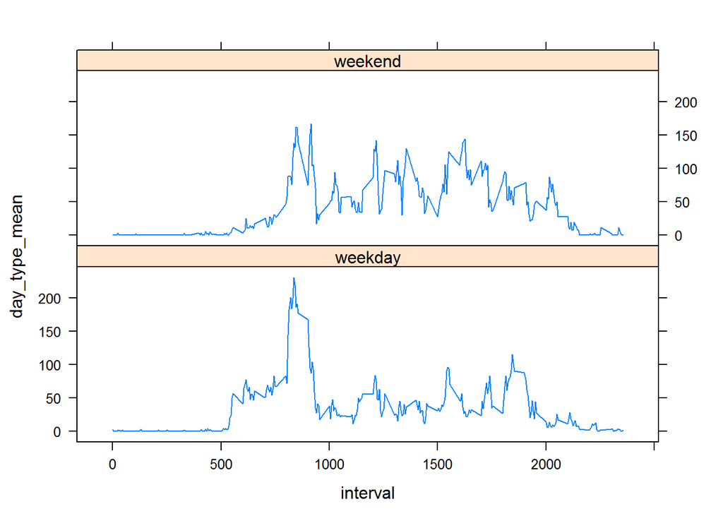

```r
imputed_data_t <- group_by(imputed_data_t, interval,day_type,day_type_mean)
imputed_data_t <- summarise(imputed_data_t, step_sum = sum(steps))
xyplot(day_type_mean ~ interval | day_type, data = imputed_data_t, type = "l", layout = c(1,2))
```

*End of assignment.*  
Thank you for reading this document.